# Chap 15. Statistical inference

- Statistical inference : the part of statistics that helps distinguish patterns arising from signal from those arising from chance

[output not shown]

# **15.1 Polls**

- Poll 여론조사 : 작은 집단을 대상으로 조사한 후 이를 바탕으로 전체 집단의 의견을 추정하는 것
- “Inference” : 위의 과정을 진행하는 통계학적인 이론

예) 대통령 선거에서 당선 예측

- Terms in polls
1. Spread : the estimated difference between support for the two candidates
2. MoE : Marging of error
3. estimates
4. Confidence intervals
5. p-values
- final goal : to understand probabilistic statements about the probability of a candidate winning, we will have about **Bayesian modeling**

[output not shown]

## 15.1.1 The sampling model for polls

- Make the example

[output not shown]

- Assume there are just two parties : Republican(Blue), Democratic(Red)

[output not shown]

# **15.2 Populations, samples, parameters, and estimates**

- prediction : the proportion of blue beads in the urn $= p = Pr(blue\ beads)$
- $1-p = Pr(red\ beads)$
- spread : $p-(1-p) = 2p-1$
- Population : the beads in the urn
- Parameter : the proportion of blue beads in the population $p$
- Sample : the 25 beads we see in the previous plot

> Are we ready to predict with certainty that there are more red beads than blue in the jar?
- we have only one $p$ using only the information we observe.
- **Sample proportion is a **“random variable”**

  `take_poll(25)`를 여러 번 돌리면 그때마다 다른 $p$값을 걷게될 것

[output not shown]

## 15.2.1 The sample average

- Sample average(표본평균의 평균, $\bar{X}$)

$$\bar{X}=1/N\times\sum_{i=1}^{N}X_i$$

[output not shown]

## 15.2.2 Parameters

- parameter : to define unknown parts of our models
- Since our main goal is figuring out what is $p$, we are going to estimate this parameter.

[output not shown]

## 15.2.3 Polling versus forecasting

- people’s opinions fluctuate through time -> $p$ might be change
- Forcasting : Poll을 바탕으로 시간이 지남에 따라 어떻게 $p$가 변화하는지 모델을 만들어 당일의 결과를 예측하는 것.

[output not shown]

## 15.2.4 Properties of our estimate : expected value and standard error

- sample proportion $\bar{X}$ (the sum of independent draws)
- **$\bar{X}$ is the parameter of interest $p$**
- expected value

$$N\bar{X} = N\times mean(p) \\
E(\bar{X}) = p$$

- standard error of the average
- incresing $N$, than decrease the standard error (the law of large numbers)
- we can calculate what is the “large enough”. (e.g.$SE(\bar{X})<0.01$)

$$SE(\bar{X}) = \sqrt{p(1-p)/N}$$

[output not shown]

[output cut: 20 more lines]

# **15.3 Exercises**

1. Suppose you poll a population in which a proportion $p$ of voters are Democrats and $1-p$ are Republicans. Your sample size is $N=25$. Consider the random variable $S$ which is the **total** number of Democrats in your sample. What is the expected value of this random variable?

$$S= E(N \times\bar{X}) = N \times E(\bar{X}) = N \times p = 25p$$

2. What is the standard error of $S$?

$$SE(S) = SE(N\times\bar{X}) = N \times SE(\bar{X}) = N * \sqrt{p(1-p)/N}$$

3. Consider the random variable $S/N$. This is equivalent to the sample average, which we have been denoting as $\bar{X}$. What is the expected value of the $\bar{X}$?

$p$

4. What is the standard error of $\bar{X}$?

$$\sqrt{p(1-p)/N}$$

5. Write a line of code that gives you the standard error `se` for the problem above for several values of $p$, specifically for `p <- seq(0, 1, length = 100).` Make a plot of `se` versus `p`.

[output not shown]

6. Copy the code above and put it inside a for-loop to make the plot for N=25, N=100, and N=1000

[figure not shown]

7. If we are interested in the difference in proportions, $p-(1-p)$, our estimate is $d=\bar{X}-(1-\bar{X})$. Use the rules we learned about sums of random variables and scaled random variables to derive the expected value of $d$.

$$E(d)=E(\bar{X}-(1-\bar{X}))=E(2\bar{X}-1)=2E(\bar{X})-1 = 2p-1$$

8. What is the standard error of $d$?

$$SE(d)=2SE(\bar{X})-1=2\sqrt{p(1-p)/N}$$

9. If the actual $p=0.45$, it means the Republicans are winning by a relatively large margin since $d=-0.1$, which is a 10% margin of victory. In this case, what is the standard error of $2\hat{X}-1$ if we take a sample of $N=25$?

[output not shown]

10. Given the answer to 9, which of the following best describes your strategy of using best describes your strategy of using a sample size of $N=25$?
1. The expected value of our estimate $2\bar{X}-1$ is $d$, so our prediction will be right on.

**b. Our standard error is larger than difference, so the chances of $2\bar{X}-1$ being positive and throwing us off were not that small. We should pick a large sample size.**

3. The difference is 10% and the standard error is about 0.2, therefore much smaller than the difference.
4. Because we don’t know $p$, we have no way of knowing that making $N$ larger would actually improve our standard error.

# **15.4 Central Limit Theorem in practice

When N is large enough,

$$\bar{X} \sim N(p, \sqrt{p\times(1-p)/N})$$
Now how does this help us? Suppose we want to know what is the probability that we are within 1% from $p$. We are basically asking what is : $Pr(|\bar{X}-p| <= 0.01)$

$$Pr(|\bar{X}-p| \leqq 0.01)\\
\Leftrightarrow Pr(\bar{X} \leqq p+0.01) - Pr(\bar{X} \leqq p-0.01)\\
\Leftrightarrow Pr(Z \leqq 0.01/SE(\bar{X})) - Pr(X \leqq -0.01/SE(\bar{X}))$$

One problem we have is that since we don’t know $p$, we don’t know $SE(\bar{X})$. But it turns out that **the CLT still works** if we estimate the standard error by using $\bar{X}$ in place of $p$. We say that we plug-in the estimate. Our estimate of the standard error is therefore:

$$\hat{SE}(\bar{X})=\sqrt{\bar{X}(1-\bar{X})/N}$$

In our first sample we had 12 blue and 13 red so $\bar{X}=0.48$ and our estimate of standard error is:

[output not shown]

and now we can answer the question of the probability of being close to $p$. The answer is:

추정값—> 실제값

$$\Rightarrow N=25\ is\ not\ large\ enough$$

Earlier we mentioned **the margin of error**. Now we can define it because it is simply two times the standard error, which we can now estimate. In our case it is:

[output not shown]

Why do we multiply by 1.96? Because if you ask what is the probability that we are within 1.96 standard errors from $p$, we get:

$$Pr(Z\leqq1.96SE(\bar{X})/SE(\bar{X}))-Pr(Z\leqq-1.96SE(\bar{X})/SE(\bar{X}))\\
\Leftrightarrow Pr(Z\leqq1.96)-Pr(Z\leqq-1.96)$$

which we know is about 95%

```
`data_frame()` is deprecated, use `tibble()`.
```

[figure not shown]

In summary, the CLT tells us that our poll based on a sample size of 25 is not very useful. We don’t really learn much when the margin of error is this large. All we can really say is that the popular vote will not be won by a large margin. This is why pollsters tend to use larger sample sizes.

## 15.4.1 A Monte Carlo simulation

Suppose we want to use a Monte Carlo simulation to corroborate the tools we have built using probability theory. To create the simulation, we would write code like this:

[figure not shown]

One thing we therefore do to corroborate theoretical results is to pick one or several values of `p` and run the simulations. Let’s set `p=0.45`. We can then simulate a poll:

[output not shown]

In this particular sample, our estimate is x_hat. We can use that code to do a Monte Carlo simulation

[output not shown]

```r
mean(x_hat)
```

[output not shown]

```r
sd(x_hat)
```

[output not shown]

## 15.4.3 Bias : why not run a very large poll?

One reason is that running such a poll is very expensive. Another possibly more important reason is that theory has its limitations. Polling is much more complicated than picking beads from an urn. Some people might lie to pollsters and others might not have phones. But perhaps the most important way an actual poll differs from an urn model is that we actually don’t know for sure who is in our population and who is not. How do we know who is going to vote? Are we reaching all possible voters? Hence, even if our margin of error is very small, it might not be exactly right that our expected value is  
p . We call this bias. Historically, we observe that polls are indeed biased, although not by that much. The typical bias appears to be about 1-2%. This makes election forecasting a bit more interesting and we will talk about how to model this in a later chapter.

# **15.5 Exercises**

1. Write an urn model function that takes the proportion of Democrats $p$ and the sample size $N$ as arguments and returns the sample average if Democrats are 1s and Republicans are 0s. Call the fucntion `take_sample`.

```r
take_sample <- function(p, N){
  x <- sample(c(0,1), size=N, replace=TRUE, prob=c(1-p, p))
  mean(x)
}  #democrates are 1s and republicans are 0s
```

2. Now assume `p <- 0.45` and that your sample size is $N=100$. Take a sample 10,000 times and save the vector of `mean(X)-p` into an object called `errors`.

```r
p <- 0.45
N <- 100
B <- 10000
errors <- replicate(B, take_sample(p, N)-p)
```

3. The vectors `errors` contains, for each simulated sample, the difference between the actual $p$ and our estimate $\bar{X}$. We refer to this difference as the error. Compute the average and make a histogram of the errors generated in the Monte Carlo simulation and select which of the following best describes their distributions :

```r
mean(errors)
```

```r
hist(errors)
```

1. The errors are all about 0.05.
2. The errors are all about -0.05. **c. The errors are symmetrically distributed around 0.**
3. The errors range from -1 to 1.
4. The error $\bar{X}-p$ is a random variable. In practice, the error is not observed because we do not know $p$. Here we observe it because we constructed the simulation. What is the average size of the errror if we define the size by taking the absolute value $|\bar{X}-p|$?

```r
mean(abs(errors))
```

5. The standard error is related to the typical size of the error we make when predicting. We say size because we just saw that the errors are centered around 0, so thus the average error value is 0. For mathematical reasons related to the Central Limit Theorem, we actually use the standard deviation of errors rather than the average of the absolute values to quantify the typical size. What is this standard deviation of the errors?

```r
sqrt(mean(errors^2))
```

6. The theory we just learned tells us what this standard deviation is going to be because it is the standard error of $\bar{X}$. What does theory tell us is the standard error of ${X} for a sample size of 100?

```r
N <- 100
sqrt(p*(1-p)/N)
```

7. In practice, we don’t know $p$ , so we construct an estimate of the theoretical prediction based by plugging in $\bar{X}$ for $p$ . Compute this estimate. Set the seed at 1 with `set.seed(1)`.

```r
set.seed(1)
x <- sample(c(0,1), size=N, replace=TRUE, prob = c(1-p,p))
x_bar <- mean(x)
sqrt(x_bar*(1-x_bar)/N)
```

Q1.

```r
replicate(B, take_sample(2000, 0.6))
```

[output not shown]

[output cut: 98 more lines]

Q2.

```r
sd(games)
```

```
[1] 88.07104
```

Q3.

```r
mean(games<0)
```

```
[1] 1
```

8. Note how close the standard error estimates obtained from the Monte Carlo simulation (exercise 5), the theoretical prediction (exercise 6), and the estimate of the theoretical prediction (exercise 7) are. The theory is working and it gives us a practical approach to knowing the typical error we will make if we predict $p$ with $\bar{X}$. Another advantage that the theoretical result provides is that it gives an idea of how large a sample size is required to obtain the precision we need. Earlier we learned that the largest standard errors occur for $p=0.5$. Create a plot of the largest standard error for $N$ ranging from 100 to 5,000. Based on this plot, how large does the sample size have to be to have a standard error of about 1%?

```r
N <- seq(100, 5000, 100)
p <- 0.5
se <- sqrt(p*(1-p)/N)
data_frame(N, se) %>% ggplot(aes(N, se)) + geom_point() + geom_hline(yintercept = 0.01)
```

1. 100
2. 500 **c. 2,500**
3. 4,000
9. For sample size $N=100$, the central limit theorem tells us that the distribution of $\bar{X}$ is:
1. practically equal to $p$.

**b. approximately normal with expected value $p$ and standard error $\sqrt{p(1−p)/N}$.**

3. approximately normal with expected value $\bar{X}$ and standard error $\sqrt{\bar{X}(1−\bar{X})/N}$ .
4. not a random variable.
10. Based on the answer from exercise 8, the error $\bar{X}−p$ is:
1. practically equal to 0.
2. approximately normal with expected value 0 and standard error $\sqrt{p(1−p)/N}$

4. not a random variable.
11. To corroborate your answer to exercise 9, make a qq-plot of the `errors` you generated in exercise 2 to see if they follow a normal distribution.

```r
qqnorm(errors)
```

12. If $p = 0.45$ and $N = 100$ as in exercise 2, use the CLT to estimate the probability that $\bar{X} > 0.5$. You can assume you know $p = 0.45$ for this calculation.

```r
p <- 0.45
N <- 100
1-pnorm(0.5, p, sqrt(p*(1-p)/N))
```

13. Assume you are in a practical situation and you don’t know $p$ . Take a sample of size $N=100$ and obtain a sample average of $\bar{X}=0.51$. What is the CLT approximation for the probability that your error is equal to or larger than 0.01?

```r
x_bar <- 0.51
N <- 100
se_bar <- sqrt(x_bar*(1-x_bar)/N)
1 - pnorm(0.01, 0, se_bar) + pnorm(-0.01, 0, se_bar)
```

# **15.6 Confidence intervals

- The definition of “Confidence intervals”

We can use the statistical theory we have learned to compute the probability of any given interval including $p$. If we are asked to create an interval with, say, a **95% chance of including $p$**, we can do that as well. These are called 95% confidence intervals.

When a pollster reports an estimate and a margin of error, they are, in a way, reporting a 95% confidence interval. Let’s show how this works mathematically.

We want to know the probability that the interval $[\bar{X}-2\hat{SE}(\bar{X}),\bar{X}+2\hat{SE}(\bar{X}]$ contains the true proportion $p$. First, consider that the start and end of these intervals are random variables: every time we take a sample, they change. To illustrate this, run the Monte Carlo simulation above twice. We use the same parameters as above:

```r
p <- 0.45
N <- 1000
```

And notice that the interval here:

```r
c(x_hat - 1.96 * se_hat, x_hat + 1.96 * se_hat)
```

```
[1] 0.4400618 0.5019382
```

is different from this one :

```r
c(x_hat - 1.96 * se_hat, x_hat + 1.96 * se_hat)
```

```
[1] 0.4032809 0.4647191
```

Keep sampling and creating intervals and you will see the **random variation**.

To determine the probability that the interval includes $p$, we need to compute this :

$$Pr(\bar{X} - 1.96\hat{SE}(\bar{X}) <= p <= \bar{X} + 1.96\hat{SE}(\bar{X}))$$

By subtracting and dividing the same quantities in all parts of the equation, we get that the above in equivalent to:

$$Pr(-1.96 <= (\bar{X}-p)/\hat{SE}(\bar{X})<= 1.96)$$

The term in the middle is an approximately normal random variable with expected value 0 and standard error 1, which we have been denoting with $Z$, so we have:

$$Pr(-1.96 <= Z <= 1.96)$$

which we can quickly compute using :

```r
pnorm(1.96) - pnorm(-1.96)
```

```
[1] 0.9500042
```

proving that we have a 95% probability.

- If we want to have a larger probability, say 99%, we need to multiply by whatever z satisfies the following:

$$Pr(-z <= Z <= z) =0.99$$

Using :

```r
z
```

```
[1] 2.575829
```

will achieve this because by definition `pnorm(qnorm(0.995))` is 0.995 and by symmetry `pnorm(1-qnorm(0.995))` is 1 - 0.995. As a consequence, we have that:

```r
pnorm(z) - pnorm(-z)
```

```
[1] 0.99
```

## 15.6.1 A Monte Carlo simulation

We can run a Monte Carlo simulation to confirm that, in fact, a 95% confidence interval includes $p$ 95% of the time.

```r
mean(inside)
```

```
[1] 0.9498
```

## 15.6.2 The correct language

# **15.7 Exercises**

For these exercises, we will use actual polls from the 2016 election. You can load the data from the **dslabs** package.

```r
data("polls_us_election_2016")
```

```
data set ‘polls_us_election_2016’ not found
```

Spectifically, we will use all the national polls that ended within one week before the election.

```r
library(tidyverse)
polls <- polls_us_election_2016 %>%
  filter(enddate >= "2016-10-31" & state =="U.S.")
```

1. For the first poll, you can obtain the sample size and estimated Clinton percentage with :

```r
N <- polls$samplesize[1]
x_hat <- polls$rawpoll_clinton[1]/100
```

Assume there are only two candidates and construct a 95% confidence interval for the election night proportion $p$.

```r
c(x_hat - 1.96*se_hat, x_hat + 1.96*se_hat)
```

```
[1] 0.4492381 0.4907619
```

2. Now use `dplyr` to add a confidence interval as two columns, call them `lower` and `upper`, to the object `poll`. Then use `select` to show the `pollster`, `enddate`, `x_hat`,`lower`, `upper` variables. Hint: define temporary columns `x_hat` and `se_hat`.

| pollster | enddate | x_hat | lower | upper |
| --- | --- | --- | --- | --- |
| ABC News/Washington Post | 2016-11-06 | 0.4700 | 0.4492381 | 0.4907619 |
| Google Consumer Surveys | 2016-11-07 | 0.3803 | 0.3744631 | 0.3861369 |
| Ipsos | 2016-11-06 | 0.4200 | 0.3993520 | 0.4406480 |
| YouGov | 2016-11-07 | 0.4500 | 0.4339196 | 0.4660804 |
| Gravis Marketing | 2016-11-06 | 0.4700 | 0.4624163 | 0.4775837 |
| Fox News/Anderson Robbins Research/Shaw & Company Research | 2016-11-06 | 0.4800 | 0.4527891 | 0.5072109 |
| CBS News/New York Times | 2016-11-06 | 0.4500 | 0.4241784 | 0.4758216 |
| NBC News/Wall Street Journal | 2016-11-05 | 0.4400 | 0.4128273 | 0.4671727 |
| IBD/TIPP | 2016-11-07 | 0.4120 | 0.3830052 | 0.4409948 |
| Selzer & Company | 2016-11-06 | 0.4400 | 0.4055806 | 0.4744194 |

[output cut: 60 more lines]

3. The final tally for the popular vote was Clinton 48.2% and Trump 46.1%. Add a column, call it hit, to the previous table stating if the confidence interval included the true proportion $p=0.482$ or not.

| pollster | enddate | x_hat | lower | upper | hit |
| --- | --- | --- | --- | --- | --- |
| ABC News/Washington Post | 2016-11-06 | 0.4700 | 0.4492381 | 0.4907619 | 1 |
| Google Consumer Surveys | 2016-11-07 | 0.3803 | 0.3744631 | 0.3861369 | 0 |
| Ipsos | 2016-11-06 | 0.4200 | 0.3993520 | 0.4406480 | 0 |
| YouGov | 2016-11-07 | 0.4500 | 0.4339196 | 0.4660804 | 0 |
| Gravis Marketing | 2016-11-06 | 0.4700 | 0.4624163 | 0.4775837 | 0 |
| Fox News/Anderson Robbins Research/Shaw & Company Research | 2016-11-06 | 0.4800 | 0.4527891 | 0.5072109 | 1 |
| CBS News/New York Times | 2016-11-06 | 0.4500 | 0.4241784 | 0.4758216 | 0 |
| NBC News/Wall Street Journal | 2016-11-05 | 0.4400 | 0.4128273 | 0.4671727 | 0 |
| IBD/TIPP | 2016-11-07 | 0.4120 | 0.3830052 | 0.4409948 | 0 |
| Selzer & Company | 2016-11-06 | 0.4400 | 0.4055806 | 0.4744194 | 0 |

[output cut: 60 more lines]

4. For the table you just created, what proportion of confidence intervals included $p$ ?

```r
sum(poll$hit) / length(poll$hit)
```

```
[1] 0.3142857
```

5. If these confidence intervals are constructed correctly, and the theory holds up, what proportion should include $p$ ?

> 95%
6. A much smaller proportion of the polls than expected produce confidence intervals containing $p$ . If you look closely at the table, you will see that most polls that fail to include $p$ are underestimating. The reason for this is undecided voters, individuals polled that do not yet know who they will vote for or do not want to say. Because, historically, undecideds divide evenly between the two main candidates on election day, it is more informative to estimate the spread or the difference between the proportion of two candidates $d$ , which in this election was $0.482-0.461=0.021$ . Assume that there are only two parties and that $d=2p−1$ , redefine `polls` as below and re-do exercise 1, but for the difference.

```r
polls <- polls_us_election_2016 %>%
  filter(enddate >= "2016-10-31" & state == "U.S.")  %>%
  mutate(d_hat = rawpoll_clinton / 100 - rawpoll_trump / 100)
```

difference=차분?

```r
temp[2] - temp[1]
```

```
[1] 0.08304748
```

7. Now repeat exercise 3, but for the difference.

| pollster | enddate | d_hat | lower | upper | hit |
| --- | --- | --- | --- | --- | --- |
| ABC News/Washington Post | 2016-11-06 | 0.0400 | -0.001564627 | 0.0815646272 | TRUE |
| Google Consumer Surveys | 2016-11-07 | 0.0234 | 0.011380104 | 0.0354198955 | TRUE |
| Ipsos | 2016-11-06 | 0.0300 | -0.011815309 | 0.0718153088 | TRUE |
| YouGov | 2016-11-07 | 0.0400 | 0.007703641 | 0.0722963589 | TRUE |
| Gravis Marketing | 2016-11-06 | 0.0400 | 0.024817728 | 0.0551822719 | FALSE |
| Fox News/Anderson Robbins Research/Shaw & Company Research | 2016-11-06 | 0.0400 | -0.014420872 | 0.0944208716 | TRUE |
| CBS News/New York Times | 2016-11-06 | 0.0400 | -0.011860967 | 0.0918609675 | TRUE |
| NBC News/Wall Street Journal | 2016-11-05 | 0.0400 | -0.014696100 | 0.0946961005 | TRUE |
| IBD/TIPP | 2016-11-07 | -0.0150 | -0.073901373 | 0.0439013728 | TRUE |
| Selzer & Company | 2016-11-06 | 0.0300 | -0.039307332 | 0.0993073320 | TRUE |

[output cut: 60 more lines]

8. Now repeat exercise 4, but for the difference.

| mean(hit) |
| --- |
| 0.7714286 |

9. Although the proportion of confidence intervals goes up substantially, it is still lower than 0.95. In the next chapter, we learn the reason for this. To motivate this, make a plot of the error, the difference between each poll’s estimate and the actual $d=0.021$ . Stratify by pollster.

[figure not shown]

10. Redo the plot that you made for exercise 9, but only for pollsters that took five or more polls.

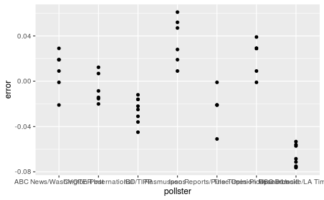

# **15.8 Power**

Pollsters are not successful at providing correct confidence intervals, but rather at predicting who will win. When we took a 25 bead sample size, the confidence interval for the spread:

```r
N <- 25
x_hat <- 0.48
(2 * x_hat -1) + c(-1.96, 1.96) * 2 * sqrt(x_hat * (1-x_hat) / N)
```

[output not shown]

includes 0. If this were a poll and we were forced to make a declaration, we would have to say it was a “toss-up”.

A problem with our poll results is that given the sample size and the value of $p$, we would have to sacrifice on the probability of an incorrect call to create an interval that does not include 0.

This does not mean that the election is close. It only means that we have a small sample size. In statistical textbooks this is called lack of power. In the context of polls, power is the probability of detecting spreads different from 0.

By increasing our sample size, we lower our standard error and therefore have a much better chance of detecting the direction of the spread.

# **15.9 p-values**

**p-values** are ubiquitous in the scientific literature. They are related to **confidence intervals** so we introduce the concept here.

Let’s consider the blue and red beads. Suppose that rather than wanting an estimate of the spread or the proportion of blue, I am interested only in the question : are there more blue beads or red beads? I want to know if the spread $2p-1>0$.

Say we take a random sample of $N=100$ and we observe 52 blue beads, which gives us $2\bar{X}-1 = 0.04$. This seems to be pointing to the existence of more bluew than red beads since 0.04 is larger than 0.

However, as data scientists we need to be skeptical. We know there is chance involved in this process and we could get a 52 even when the actual spread is 0. We call the assumption that is the skeptic’s $2p-1=0$ a **null hypotehsis**. The null hypothesis is the skeptic’s hypothesis. We have observed a random variable $2*\bar{X}-1=0.04$ and the p-value is the answer to the question : how likely is it to see a value this large, when the null hypothesis is true? So we write:

$$Pr(|\bar{X}-0.5| >0.02)$$

assuming the $2p-1=0$ or $p=0.5$. Under the null hypothesis we know that :

$$\sqrt{N}(\bar{X}-0.5)/\sqrt{0.5(1-0.5)}$$
is standard normal. We there fore can compute the probability above, which is the p-value.

$$Pr(\sqrt{N}(\bar{X}-0.5)/\sqrt{0.5(1-0.5)}>\sqrt{N}(0.02)/\sqrt{0.5(1-0.5)})$$

```r
N <- 100
z <- sqrt(N)*0.02/0.5
1 - (pnorm(z) - pnorm(-z))
```

[output not shown]

In this case, there is actually a large chance of seeing 52 or larger under the null hypothesis.

Keep in mind that there is a close connection between p-values and confidence intervals. If a 95% confidence interval of the spread does not include 0, we know that the p-value must be smaller than 0.05.

To learn more about p-values, you can consult any statistics textbook. However, in general, we prefer reporting confidence intervals over p-values since it gives us an idea of the size of the estimate. If we just report the p-value we provide no information about the significance of the finding in the context of the problem.

# **15.10 Association tests**

The statistical tests we have studied up to now leave out a substantial portion of data types. Specifically, we have not discussed inference for binary, categorical, and ordinal data. To give a very specific example, consider the following case study.

A 2014 PNAS paper analyzed success rates from funding agencies in the Netherlands and concluded that their:

> results reveal gender bias favoring male applicants over female applicants in the prioritization of their “quality of researcher” (but not “quality of proposal”) evaluations and success rates, as well as in the language use in instructional and evaluation materials.

The main evidence for this conclusion comes down to a comparison of the percentages. Table S1 in the paper includes the information we need. Here are the three columns showing the overall outcomes:

```r
library(tidyverse)
library(dslabs)
data("research_funding_rates")
research_funding_rates %>% select(discipline, applications_total, success_rates_total) %>% head()
```

We have these values for each gender:

```r
names(research_funding_rates)
```

We can compute the totals that were successful and the totals that were not as follows:

```r
totals <- research_funding_rates %>%
  select(-discipline) %>%
  summarize_all(sum) %>%
  summarize(yes_men = awards_men,
            no_men = applications_men - awards_men,
            yes_women = awards_women,
            no_women = applications_women - awards_women)
```

So we see that a larger percent of men than women received awards :

```r
totals %>% summarize(percent_men = yes_men/(yes_men+no_men),
                     percent_women = yes_women/(yes_women+no_women))
```

[output not shown]

But could this be due just to random variability? Here we learn how to perform inference for this type of data.

## 15.10.1 Lady Testing Tea (Fisher’s exact test)

R.A. Fisher53 was one of the first to formalize hypothesis testing. The “Lady Tasting Tea” is one of the most famous examples.

The story is as follows: an acquaintance of Fisher’s claimed that she could tell if milk was added before or after tea was poured. Fisher was skeptical. He designed an experiment to test this claim. He gave her four pairs of cups of tea: one with milk poured first, the other after. The order was randomized. The null hypothesis here is that she is guessing. Fisher derived the distribution for the number of correct picks on the assumption that the choices were random and independent.

As an example, suppose she picked 3 out of 4 correctly. Do we believe she has a special ability? The basic question we ask is: if the tester is actually guessing, what are the chances that she gets 3 or more correct? Just as we have done before, we can compute a probability under the null hypothesis that she is guessing 4 of each. Under this null hypothesis, we can think of this particular example as picking 4 balls out of an urn with 4 blue (correct answer) and 4 red (incorrect answer) balls. Remember, she knows that there are four before tea and four after.

Under the null hypothesis that she is simply guessing, each ball has the same chance of being picked. We can then use combinations to figure out each probability. The probability of picking 3 is $(^4_3)(^4_1)/(^8_4)=16/70$. The probability of picking all 4 correct is $(^4_4)(^4_0)/(^8_4)=1/70$. Thus, the chance of observing a 3 or something more extreme, under the null hypothesis, is $\sim 0.24$. This is the p-value. The procedure that produced this p-value is called **Fisher’s exact test** and it uses the hypergeometric distribution.

## 15.10.2 Two-by-two tables

The data from the experiment is usually summarized by a table like this :

```r
tab <- matrix(c(3,1,1,3),2,2)
rownames(tab)<-c("Poured Before","Poured After")
colnames(tab)<-c("Guessed before","Guessed after")
tab
```

These are referred to as a two-by-two table. For each of the four combinations one can get with a pair of binary variables, they show the observed counts for each occurrence.

The function `fisher.test` performs the inference calculations above:

```r
fisher.test(tab, alternative="greater")$p.value
```

[output not shown]

## 15.10.3 Chi-square Test

Notice that, in a way, our funding rates example is similar to the Lady Tasting Tea. However, in the Lady Tasting Tea example, the number of blue and red beads is experimentally fixed and the number of answers given for each category is also fixed. This is because Fisher made sure there were four cups with milk poured before tea and four cups with milk poured after and the lady knew this, so the answers would also have to include four befores and four afters. If this is the case, the sum of the rows and the sum of the columns are fixed. This defines constraints on the possible ways we can fill the two by two table and also permits us to use the hypergeometric distribution. In general, this is not the case. Nonetheless, there is another approach, the Chi-squared test, which is described below.

Imagine we have 290, 1,345, 177, 1,011 applicants, some are men and some are women and some get funded, whereas others don’t. We saw that the success rates for men and woman were:

```r
totals %>% summarize(percent_men = yes_men/(yes_men+no_men),
                     percent_women = yes_women/(yes_women+no_women))
```

respectively. Would we see this again if we randomly assign funding at the overall rate:

```r
rate <- totals %>%
  summarize(percent_total =
              (yes_men + yes_women)/
              (yes_men + no_men +yes_women + no_women)) %>%
  pull(percent_total)
rate
```

The Chi-square test answers this question. The first step is to create the two-by-two data table:

```r
two_by_two <- data.frame(awarded = c("no", "yes"),
                     men = c(totals$no_men, totals$yes_men),
                     women = c(totals$no_women, totals$yes_women))
two_by_two
```

The general idea of the Chi-square test is to compare this two-by-two table to what you expect to see, which would be:

```r
data.frame(awarded = c("no", "yes"),
       men = (totals$no_men + totals$yes_men) * c(1 - rate, rate),
       women = (totals$no_women + totals$yes_women) * c(1 - rate, rate))
```

[output not shown]

We can see that more men than expected and fewer women than expected received funding. However, under the null hypothesis these observations are random variables. The Chi-square test tells us how likely it is to see a deviation this large or larger. This test uses an asymptotic result, similar to the CLT, related to the sums of independent binary outcomes. The R function chisq.test takes a two-by-two table and returns the results from the test:

```r
chisq_test <-two_by_two %>% select(-awarded) %>% chisq.test()
```

We see that the p-value is 0.0509:

```r
chisq_test$p.value
```

[output not shown]

## 15.10.4 The odds ratio

An informative summary statistic associated with two-by-two tables is the odds ratio. Define the two variables as $X=1$. If you are a male and 0 otherwise, and $Y=1$ if you are funded and 0 otherwise. The odds of getting funded if you are a man is defined:

$$Pr(Y=1|X=1)/Pr(Y=0|X=1)$$

and can be computed like this:

```r
odds_men <- with(two_by_two, (men[2]/sum(men))/(men[1]/sum(men)))
odds_men
```

And the odds of being funded if you are a woman is :

$$Pr(Y=1|X=0)/Pr(Y=0|X=0)$$
and can be computed like this:

```r
odds_women <- with(two_by_two, (women[2]/sum(women)) / (women[1]/sum(women)))
odds_women
```

The odds ratio is the ratio for these two odds: how many times larger are the odds for men than for women?

```r
odds_men / odds_women
```

We often see two-by-two tables written out as

[output not shown]

Inthis cases, the odds ratio is $\frac{a/c}{b/d}$ when is equivalent to $(ad)/(bc)$

## 15.10.5 Confidence intervals for the odds ratio

Computing confidence intervals for the odds ratio is not mathematically straightforward. Unlike other statistics, for which we can derive useful approximations of their distributions, the odds ratio is not only a ratio, but a ratio of ratios. Therefore, there is no simple way of using, for example, the CLT.

However, statistical theory tells us that when all four entries of the two-by-two table are large enough, then the log of the odds ratio is approximately normal with standard error

$$\sqrt{1/a + 1/b + 1/c + 1/d}$$

This implies that a 95% confidence interval for the log odds ratio can be formed by:

$$log(\frac{ad}{bc} \pm 1.96\sqrt{1/a+1/b+1/c+1/d})$$

By exponentiating these two numbers we can construct a confidence interval of the odds ratio.

Using R we can compute this confidence interval as follows:

```r
log_or <- log(odds_men / odds_women)
se <- two_by_two %>% select(-awarded) %>%
  summarize(se = sqrt(sum(1/men) + sum(1/women))) %>%
  pull(se)
ci <- log_or + c(-1,1) * qnorm(0.975) * se
```

If we want to convert it back to the odds ratio scale, we can exponentiate:

```r
exp(ci)
```

[output not shown]

Note that 1 is not included in the confidence interval which must mean that the p-value is smaller than 0.05. We can confirm this using:

```r
2*(1 - pnorm(log_or, 0, se))
```

[output not shown]

This is a slightly different p-value than that with the Chi-square test. This is because we are using a different asymptotic approximation to the null distribution. To learn more about inference and asymptotic theory for odds ratio, consult the Generalized Linear Models book by McCullagh and Nelder.

## 15.10.6 Small count correction

Note that the log odds ratio is not defined if any of the cells of the two-by-two table is 0. This is because if $a,b,c,$ or $d$ is 0, the $log\frac{ad}{bc}$ is either the log of 0 or has a 0 in the denominator. For this situation, it is common practice to avoid 0s by adding 0.5 to each cell. This is referred to as the Haldane–Anscombe correction and has been shown, both in practice and theory, to work well.

## 15.10.7 Large samples, small p-values

As mentioned earlier, reporting only p-values is not an appropriate way to report the results of data analysis. In scientific journals, for example, some studies seem to overemphasize p-values. Some of these studies have large sample sizes and report impressively small p-values. Yet when one looks closely at the results, we realize odds ratios are quite modest: barely bigger than 1. In this case the difference may not be practically significant or scientifically significant.

Note that the relationship between odds ratio and p-value is not one-to-one. It depends on the sample size. So a very small p-value does not necessarily mean a very large odds ratio. Notice what happens to the p-value if we multiply our two-by-two table by 10, which does not change the odds ratio:

```r
two_by_two %>% select(-awarded) %>%
  mutate(men = men*10, women = women*10) %>%
  chisq.test() %>% .$p.value
```

# **15.11 Exercises**

1. A famous athlete has an impressive career, winning 70% of her 500 career matches. However, this athlete gets criticized because in important events, such as the Olympics, she has a losing record of 8 wins and 9 losses. Perform a Chi-square test to determine if this losing record can be simply due to chance as opposed to not performing well under pressure.

```r
two_by_two %>% select(-record) %>% chisq.test() %>% .$p.value
```

```
[1] 0.06712074
```

2. Why did we use the Chi-square test instead of Fisher’s exact test in the previous exercise?
1. It actually does not matter, since they give the exact same p-value.
2. Fisher’s exact and the Chi-square are different names for the same test.

**c. Because the sum of the rows and columns of the two-by-two table are not fixed so the hypergeometric distribution is not an appropriate assumption for the null hypothesis. For this reason, Fisher’s exact test is rarely applicable with observational data.**

4. Because the Chi-square test runs faster.
3. Compute the odds ratio of “losing under pressure” along with a confidence interval.
4. Notice that the p-value is larger than 0.05 but the 95% confidence interval does not include 1. What explains this?
1. We made a mistake in our code.
2. These are not t-tests so the connection between p-value and confidence intervals does not apply.

**c. Different approximations are used for the p-value and the confidence interval calculation. If we had a larger sample size the match would be better.**

4. We should use the Fisher exact test to get confidence intervals.
5. Multiply the two-by-two table by 2 and see if the p-value and confidence retrieval are a better match.

```r
two_by_two %>% select(-record) %>%
  mutate(important_events = important_events*2,
         normal_events = normal_events*2) %>%
  chisq.test() %>% .$p.value
```

```
[1] 0.00544228
```